# My First Knitr Document

CRPB

## Introduction

-This is some text. Here is a code chunk. -command results = “hide” hides the result -command echo=FALSE does NOT print the code -you can name the the code chuck; this is added after you write r. In the example below, word “simulation” is the name of the code chunk

- command time <- format(Sys.time() tells you the current time
- if you write a command with a function that needs to be completed such as the one above of time, then this can be processed by stating R and the name of the function and puting it in between of the following ` `

-The Current time is Sun Jun 26 12:49:27 2016. My favorite random number is -0.6203667.

-Below is an example of an equation and its scatterplot of the data. This will be split into 2 chunks

1. Let’s first simulate some data

```r
x <- rnorm(100); y <- x + rnorm(100, sd = 0.5)
```

2. Here is a scatterplot of the data.

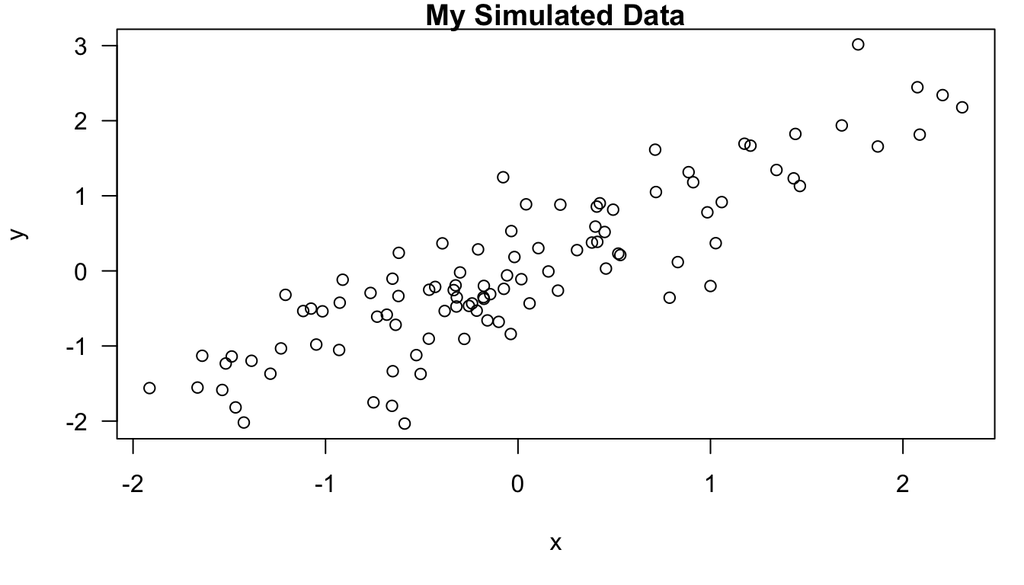

```r
par(mar =c(5, 4, 1, 1), las = 1)
plot(x, y, main = "My Simulated Data")
```

-Below is an example making a table using xtable

1. Load the data using datasets -> airquality

```r
library(datasets)
library(xtable)
data(airquality)
fit <- lm(Ozone ~ Wind + Temp + Solar.R, data = airquality)
```